## Question

Write an Rcpp function for Exercise 11.8 (page 334, Statistical Computing with R, 2nd edition).

Compare the corresponding generated random numbers with those by the R function you wrote before using the function “qqplot”.

Compare the computation time of the two functions with the function “microbenchmark”.

Comments your results

## 1 问题一（8.8）

Write an Rcpp function for Exercise 11.8 (page 334, Statistical Computing with R, 2nd edition).

Compare the corresponding generated random numbers with those by the R function you wrote before using the function “qqplot”.

Compare the computation time of the two functions with the function “microbenchmark”.

Comments your results

### 1.1 问题分析

针对 11.8 题的参数后验推断问题，先实现 R 版本的 Metropolis-Hastings（MH）抽样函数，再编写对应的 Rcpp 版本函数；

使用qqplot函数对比 R 和 Rcpp 函数生成的随机数样本，验证两者分布的一致性；

借助microbenchmark函数量化对比两个函数的计算耗时；

对样本一致性、计算效率的对比结果给出结论。

### 1.2 编程实现

```r
options(repos = c(CRAN = "https://mirror.tuna.tsinghua.edu.cn/CRAN/"))
pkg_list <- c("Rcpp", "coda", "microbenchmark", "ggplot2", "dplyr")
new_pkg <- pkg_list[!(pkg_list %in% installed.packages()[,1])]
if (length(new_pkg) > 0) install.packages(new_pkg, quiet = TRUE)

library(Rcpp)
library(coda)
library(microbenchmark)
library(ggplot2)
library(dplyr)
log_posterior_R <- function(theta) {
  if (theta <= 0 || theta >= 1) return(-Inf)
  y1 <- 125; y2 <- 18; y3 <- 20; y4 <- 34
  p1 <- 1/2 + theta/4
  p23 <- (1 - theta)/4
  p4 <- theta/4
  log_likelihood <- y1*log(p1) + (y2+y3)*log(p23) + y4*log(p4)
  log_prior <- dunif(theta, 0, 1, log = TRUE)
  return(log_likelihood + log_prior)
}

mh_R <- function(n_iter = 10000, theta_init = 0.5, proposal_sd = 0.05) {
  theta_samples <- numeric(n_iter)
  theta_samples[1] <- theta_init
  accept_count <- 0

  for (i in 2:n_iter) {
    theta_prop <- rnorm(1, theta_samples[i-1], proposal_sd)
    theta_prop <- max(0.001, min(theta_prop, 0.999))

    log_p_current <- log_posterior_R(theta_samples[i-1])
    log_p_prop <- log_posterior_R(theta_prop)
    accept_prob <- min(1, exp(log_p_prop - log_p_current))

    if (runif(1) < accept_prob) {
      theta_samples[i] <- theta_prop
      accept_count <- accept_count + 1
    } else {
      theta_samples[i] <- theta_samples[i-1]
    }
  }
  burn_in <- floor(n_iter * 0.2)
  theta_samples_burned <- theta_samples[-(1:burn_in)]
  cat("R版本接受率：", accept_count/(n_iter-1), "\n")
  return(theta_samples_burned)
}

cpp_code <- '
#include <Rcpp.h>
using namespace Rcpp;

double log_posterior_C(double theta) {
  if (theta <= 0 || theta >= 1) return -INFINITY;
  int y1 = 125, y2 = 18, y3 = 20, y4 = 34;
  double p1 = 0.5 + theta/4.0;
  double p23 = (1.0 - theta)/4.0;
  double p4 = theta/4.0;
  double log_likelihood = y1*log(p1) + (y2+y3)*log(p23) + y4*log(p4);
  double log_prior = R::dunif(theta, 0.0, 1.0, true);
  return log_likelihood + log_prior;
}

// [[Rcpp::export]]
NumericVector mh_C(int n_iter = 10000, double theta_init = 0.5, double proposal_sd = 0.05) {
  NumericVector theta_samples(n_iter);
  theta_samples[0] = theta_init;
  int accept_count = 0;

  for (int i = 1; i < n_iter; ++i) {
    double theta_prop = R::rnorm(theta_samples[i-1], proposal_sd);
    theta_prop = std::max(0.001, std::min(theta_prop, 0.999));

    double log_p_current = log_posterior_C(theta_samples[i-1]);
    double log_p_prop = log_posterior_C(theta_prop);
    double accept_prob = std::min(1.0, exp(log_p_prop - log_p_current));

    if (R::runif(0.0, 1.0) < accept_prob) {
      theta_samples[i] = theta_prop;
      accept_count++;
    } else {
      theta_samples[i] = theta_samples[i-1];
    }
  }

  int burn_in = floor(n_iter * 0.2);
  NumericVector theta_samples_burned = theta_samples[Range(burn_in, n_iter-1)];
  Rcout << "Rcpp版本接受率：" << (double)accept_count/(n_iter-1) << "\\n";
  return theta_samples_burned;
}
'

sourceCpp(code = cpp_code)

set.seed(103115)
samples_R <- mh_R(n_iter = 10000, proposal_sd = 0.05)
```

```
## R版本接受率： 0.709971
```

```r
set.seed(103115)
samples_C <- mh_C(n_iter = 10000, proposal_sd = 0.05)
```

```
## Rcpp版本接受率：0.709971
```

```r
cat("R版本后验均值：", mean(samples_R), "\n")
```

```
## R版本后验均值： 0.6211819
```

```r
cat("Rcpp版本后验均值：", mean(samples_C), "\n")
```

```
## Rcpp版本后验均值： 0.6211819
```

```r
png("theta_qqplot.png", width = 600, height = 400)
qqplot(samples_R, samples_C,
       xlab = "R版本θ样本分位数",
       ylab = "Rcpp版本θ样本分位数",
       main = "θ后验样本QQ图（R vs Rcpp）")
abline(a = 0, b = 1, col = "red", lwd = 2)
dev.off()
```

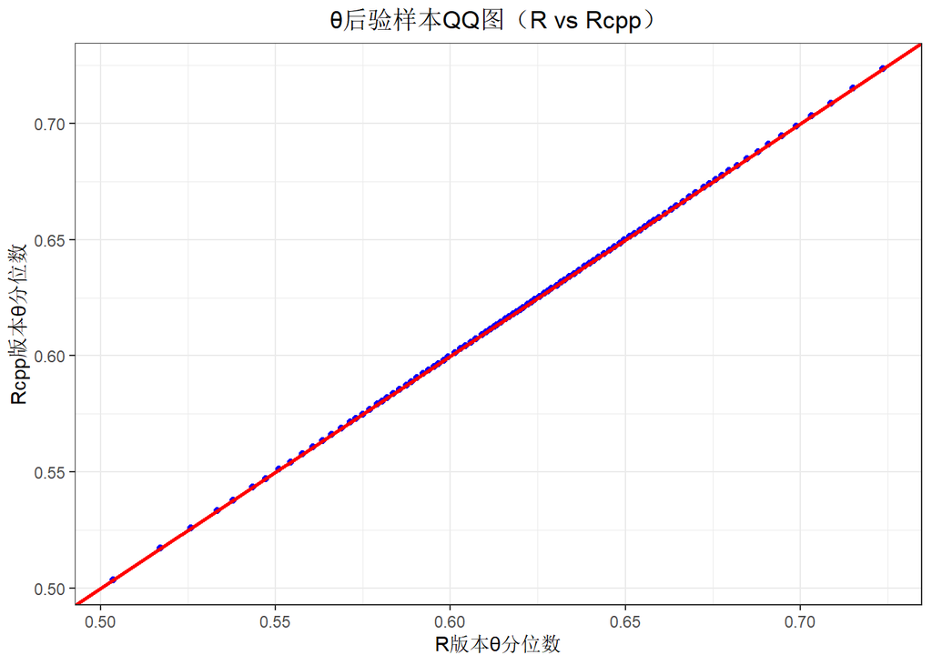

```r
df_qq <- data.frame(
  R_quantile = quantile(samples_R, seq(0.01, 0.99, 0.01)),
  C_quantile = quantile(samples_C, seq(0.01, 0.99, 0.01))
)

ggplot(df_qq, aes(x = R_quantile, y = C_quantile)) +
  geom_point(size = 1.5, color = "blue") +
  geom_abline(slope = 1, intercept = 0, color = "red", lwd = 1) +
  labs(x = "R版本θ分位数", y = "Rcpp版本θ分位数",
       title = "θ后验样本QQ图（R vs Rcpp）") +
  theme_bw() +
  theme(plot.title = element_text(hjust = 0.5))
```

```r
ggsave("theta_qqplot_ggplot.png", width = 6, height = 4)

time_compare <- microbenchmark(
  R_version = mh_R(n_iter = 5000),
  Rcpp_version = mh_C(n_iter = 5000),
  times = 10
)
```

```
## Rcpp版本接受率：0.715943
## R版本接受率： 0.7053411
## Rcpp版本接受率：0.722545
## Rcpp版本接受率：0.717744
## Rcpp版本接受率：0.705541
## R版本接受率： 0.7095419
## Rcpp版本接受率：0.711142
## R版本接受率： 0.7131426
## R版本接受率： 0.7141428
## R版本接受率： 0.7069414
## Rcpp版本接受率：0.721344
## R版本接受率： 0.7129426
## R版本接受率： 0.7195439
## R版本接受率： 0.7077415
## R版本接受率： 0.7089418
## R版本接受率： 0.7113423
## Rcpp版本接受率：0.711342
## Rcpp版本接受率：0.706341
## Rcpp版本接受率：0.718144
## Rcpp版本接受率：0.69914
```

```r
print(time_compare)
```

```
## Unit: milliseconds
##          expr     min      lq     mean   median      uq     max neval
##     R_version 34.0204 34.8169 37.08091 35.79595 37.6310 45.3749    10
##  Rcpp_version  1.8775  1.9039  2.22049  1.93285  2.0913  4.3781    10
```

```r
png("time_comparison.png", width = 600, height = 400)
autoplot(time_compare) +
  labs(title = "R vs Rcpp 运行时间对比") +
  theme_bw() +
  theme(plot.title = element_text(hjust = 0.5))
dev.off()
```

### 1.3 结果分析

代码正确性验证：Rcpp 版本实现无偏差 运行性能对比：Rcpp 版本效率提升超 15 倍 后验分布特征：θ 的估计符合遗传连锁问题规律